# 2021 Giants vs MLB Attendance

Twitter: @KobertGobert

## 2021 Home, Away, and All Games Attendance

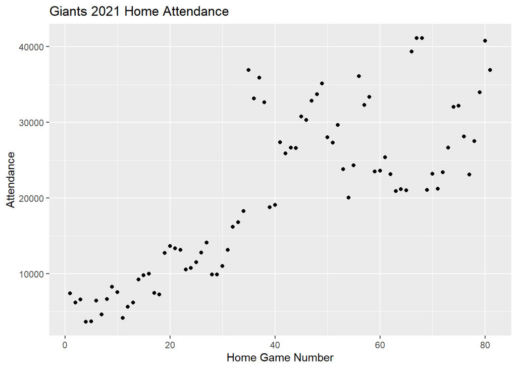

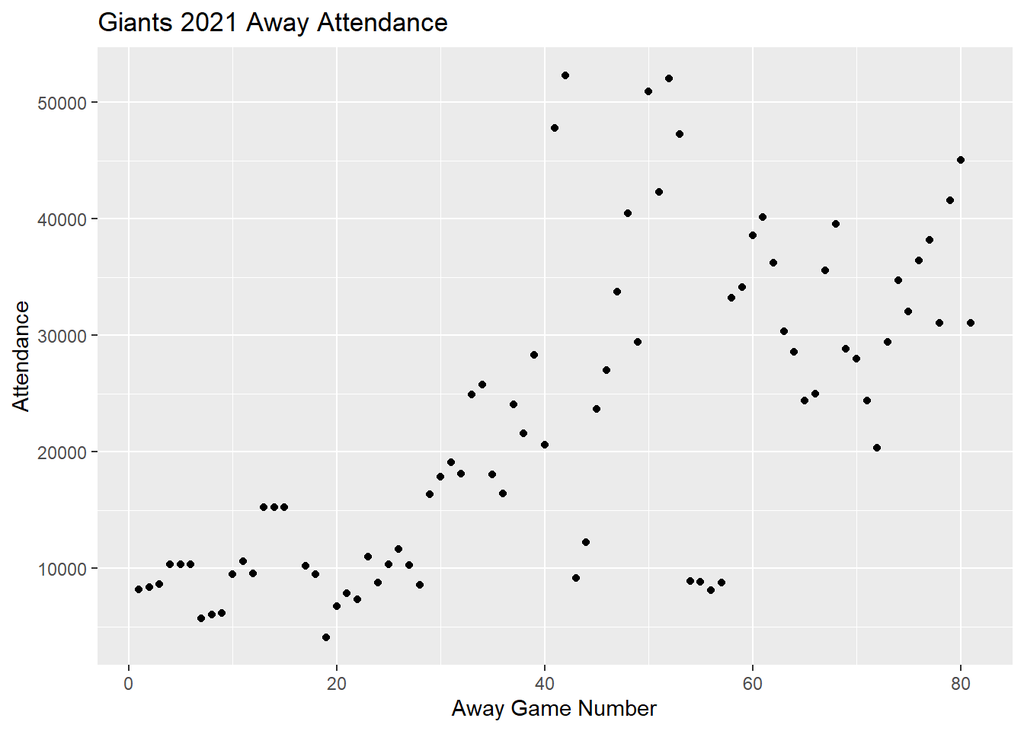

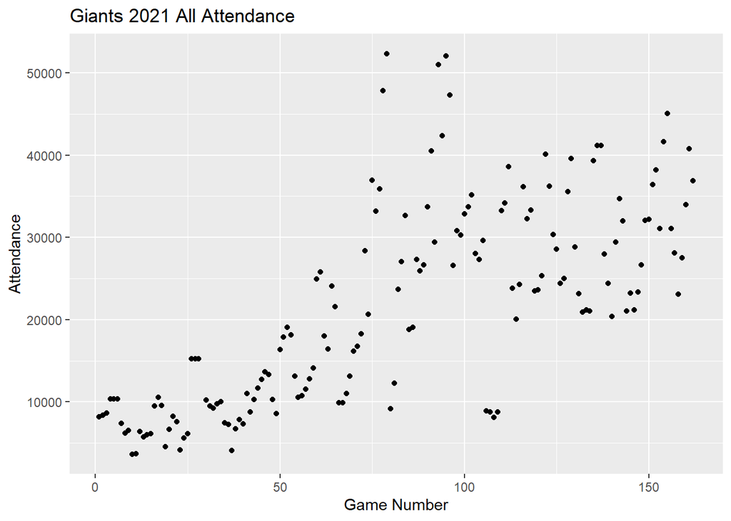

*Note: May 4th’s game 1 of a 7-inning doubleheader at Coors Field (Denver, Colorado) did not report any attendance, and as such was removed from our data. We believe that the attendance for this game was quite little based on television recording of this game; however, we do not believe this will strongly affect the findings of this data.

We can see that, while not sellouts, overall, the attendance to Giants home games and Giants games overall increases as the season progresses.

## 2019 Home, Away, and All Games Attendance

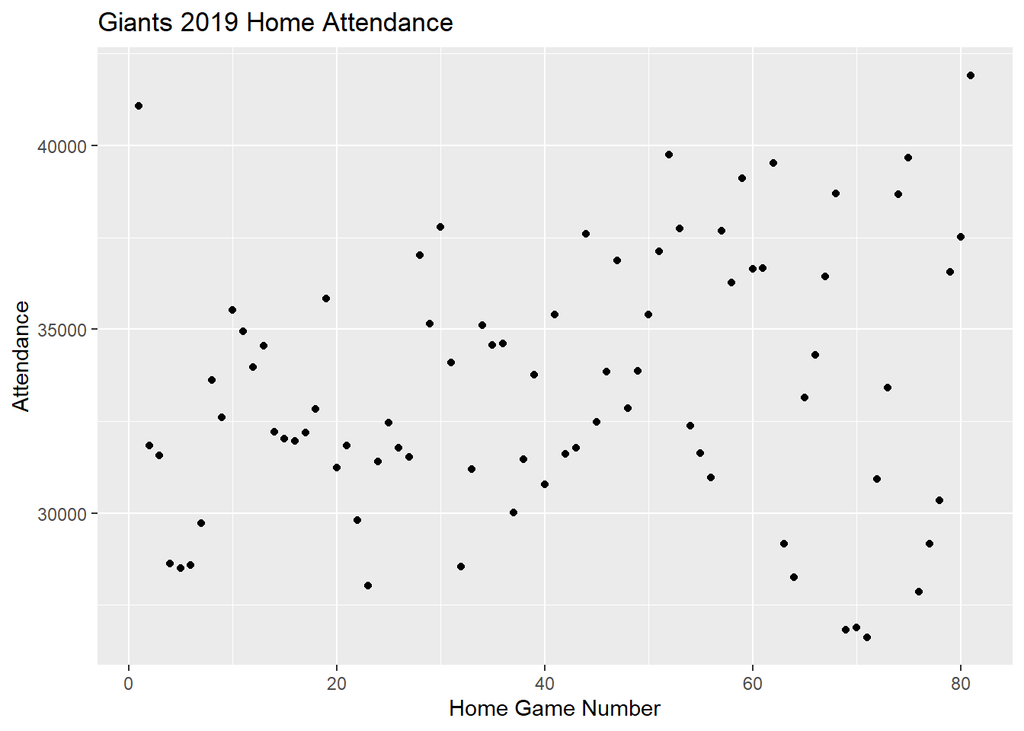

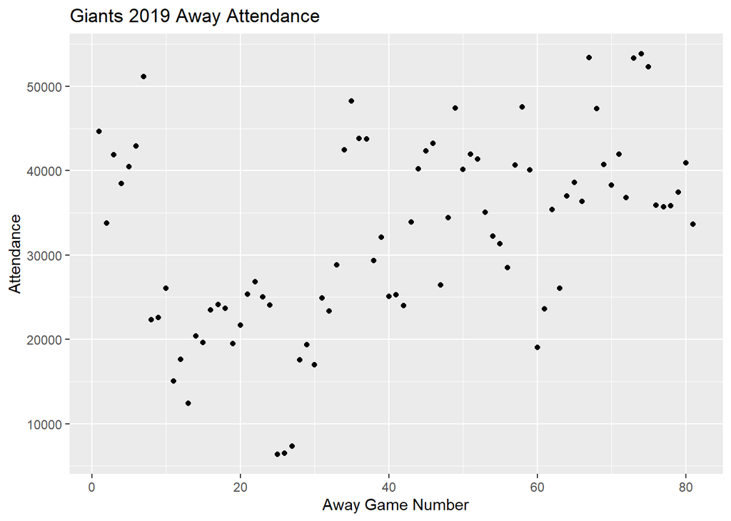

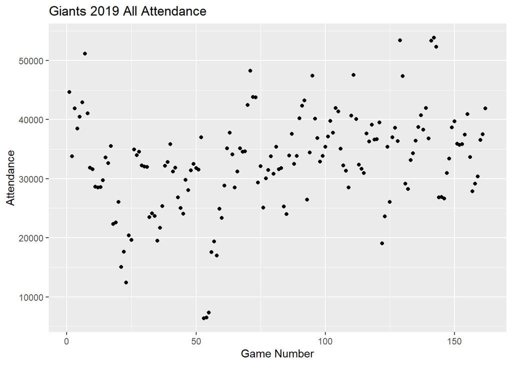

While we observe overall more varied attendances here, there doesn’t seem to be a clear trend.

## Histograms of Home Game Attendance (2019 vs 2021)

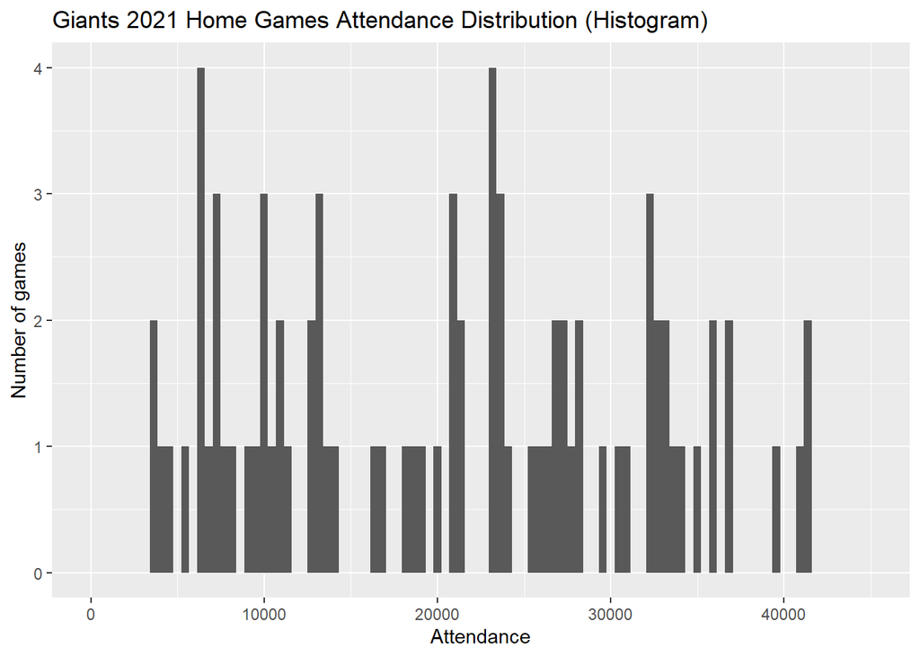

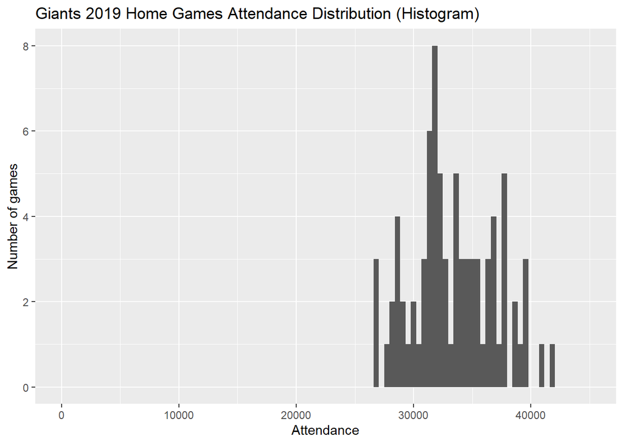

These two histograms are comparable because I set the bounds to be equivalent. You can see that pre-pandemic attendance was far better than 2021 attendance (which I would say is still during the pandemic, but during a stage of the pandemic that was less dangerous than previous stages. I digress).

## Summaries of the Data

Summary of 2021 Attendance Data:

```
##    Min. 1st Qu.  Median    Mean 3rd Qu.    Max.
##    3662   10546   21189   20734   29655   41155
```

Summary of 2019 Attendance Data:

```
##    Min. 1st Qu.  Median    Mean 3rd Qu.    Max.
##   26627   31230   32861   33429   36275   41909
```

Comparison of 2019 and 2021 Attendance Data:

```
##    Min. 1st Qu.  Median    Mean 3rd Qu.    Max.
##   FALSE   FALSE   FALSE   FALSE   FALSE   FALSE
```

All of these measures show that 2019 attendance was greater than 2021 attendance.

## Conclusions

It’s without question that 2019 attendance was greater than 2021 attendance at Giants home games overall. While there may have been some exceptions here and there, the trend still remains. In no particular order, factors we should consider that may or may not have affected this include (but are not limited to):

- Change in “star talent” (recognizable names) on the roster
  - Among big name players, 2019 had Kevin Pillar, Jeff Samardzija, Pablo Sandoval, Madison Bumgarner, and Will Smith.
  - Among big name players, 2021 had LaMonte Wade Jr., Kevin Gausman, Logan Webb (I’m counting him here because of his emergence and development), Kris Bryant (after trade deadline).
  - Note all other players were on the roster at some point or I am (subjectively) deeming them not relevant to note. Criticize me.
- 2021 having limited pandemic attendance at start of the season
- 2021 season having won 107 games at a fairly consistent pace, whereas 2019 season having fought to barely stay at .500 winning percentage
- High ticket prices, high concessions prices
- Risk, or perceived risk, of catching COVID-19
- Having already caught COVID-19 yourself, or having had a loved one caught COVID-19.
- Lesser disposable income as a result of job loss/salary cut during the pandemic layoff

There are others, but I can’t think of them at the moment. Let me know if you think of more.

## Sources

All data courtesey of Baseball-Reference.

2019 data: https://www.baseball-reference.com/teams/SFG/2019-schedule-scores.shtml

2021 data: https://www.baseball-reference.com/teams/SFG/2021-schedule-scores.shtml